# Supplementary Material for “Spatially balanced sampling methods are always more precise than random ones for estimating the size of aggregated populations”

### 1.3 Comparison of the estimated variance for SYS and SBS to the estimated variance for SRS

In this section, we represent the ratio of the variance estimated using the variance estimators for SYS and SBS over the variance estimated using the “textbook” estimator for SRS. When this ratio is below one, it means that using SYS or SBS with a given estimator yields more precise estimates than using SRS with V_textbook, and when it’s above one, it’s the opposite. The interpretation is difficult here, as several estimators present biased estimates at least for some density and aggregation levels.

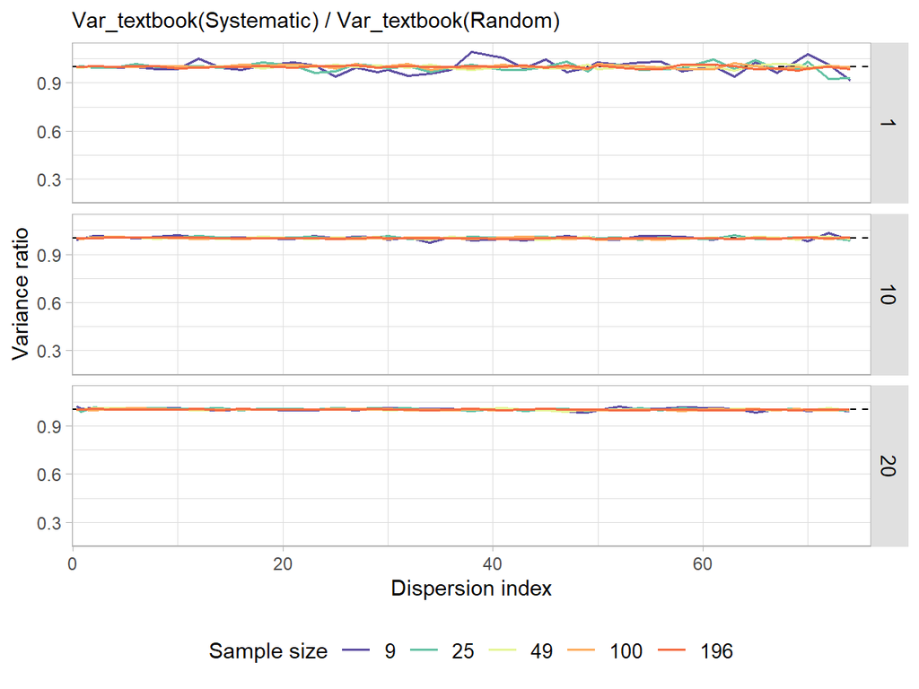

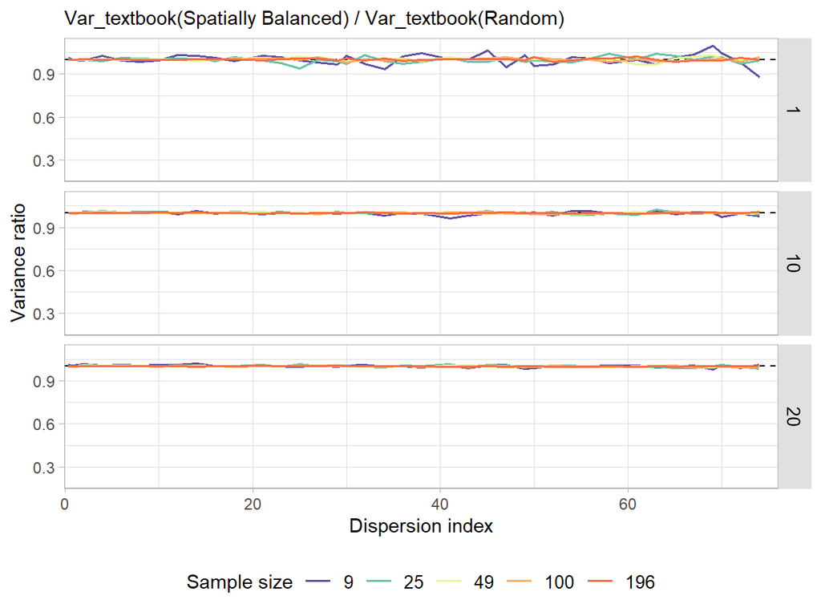

**Figure S4.7:** Ratio of the variance estimated using the “textbook” estimator for systematic sampling (SYS) and spatially balanced sampling (SBS) over the variance estimated for simple random sampling (SRS), as a function of the dispersion index (I) of the sampled populations. Panels show three different mean densities of individuals (1, 10 and 20 individuals/cell).

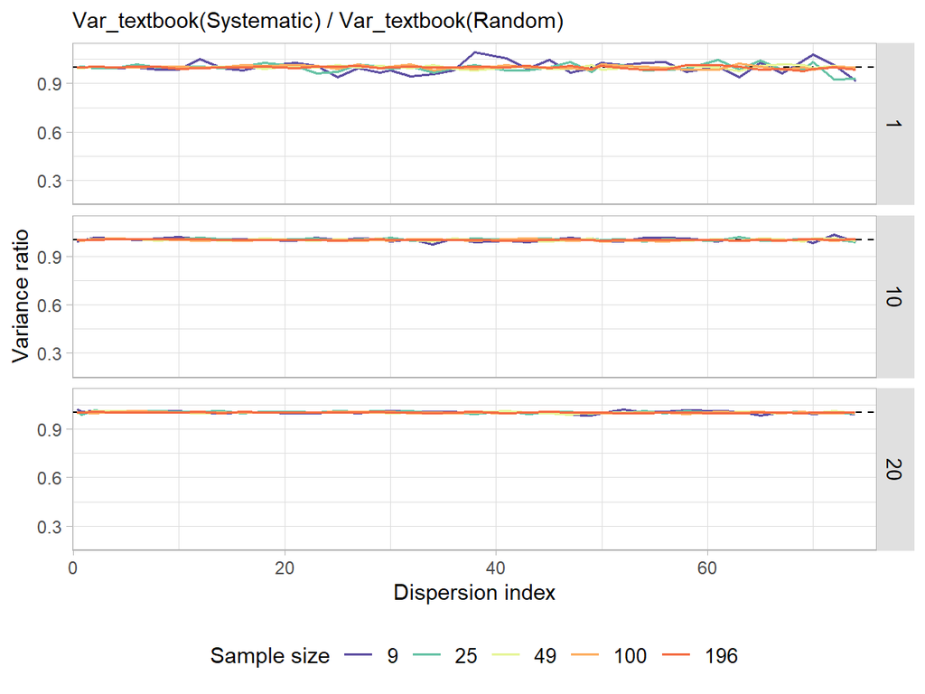

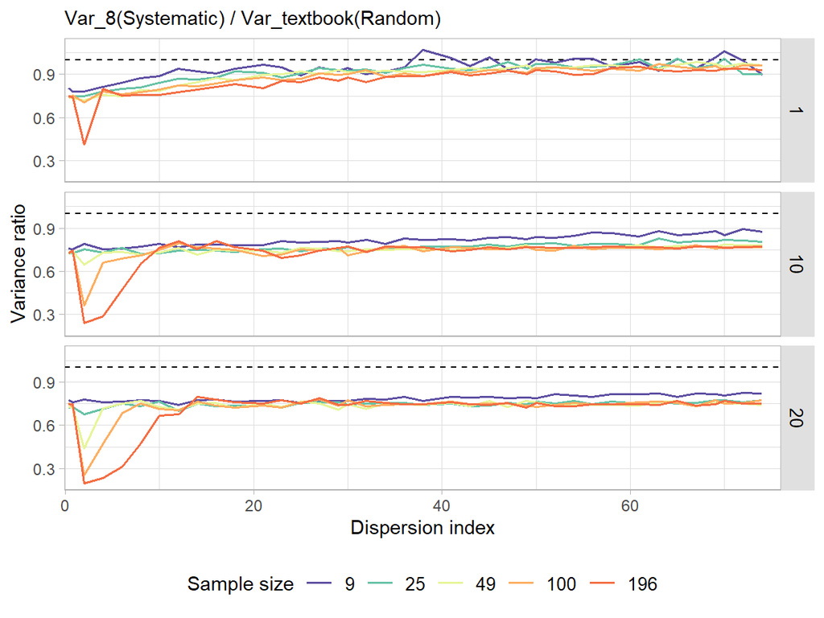

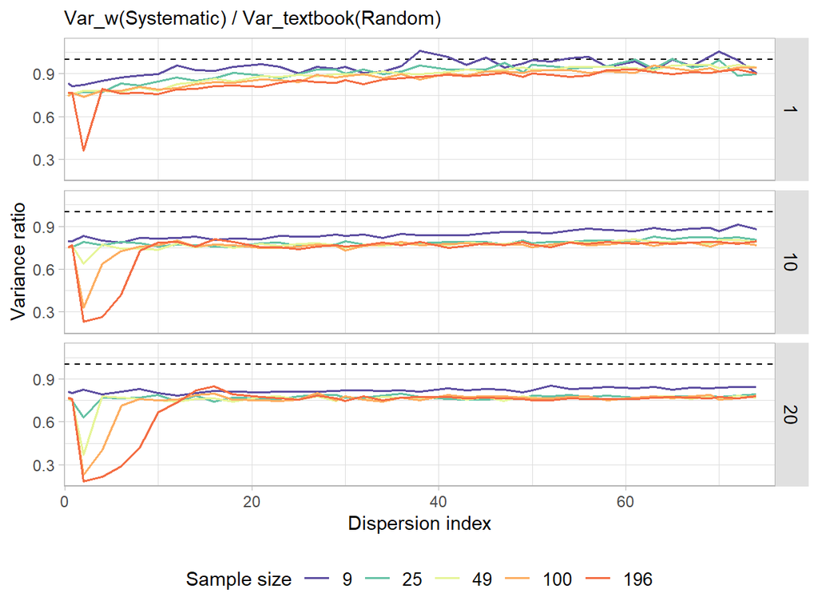

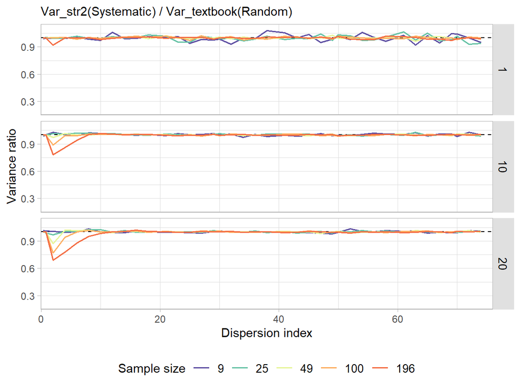

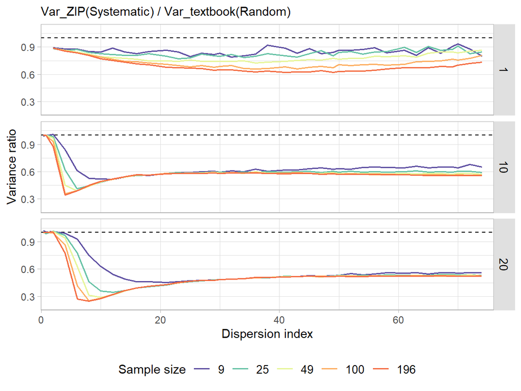

**Figure S4.8:** Ratio of the variance estimated using five variance estimators (V_textbook, V_8, V_w, V_str2, V_ZIP) for systematic sampling (SYS) over the variance estimated using the “textbook” estimator for simple random sampling (SRS), as a function of the dispersion index (I) of the sampled populations. Panels show three different mean densities of individuals (1, 10 and 20 individuals/cell).

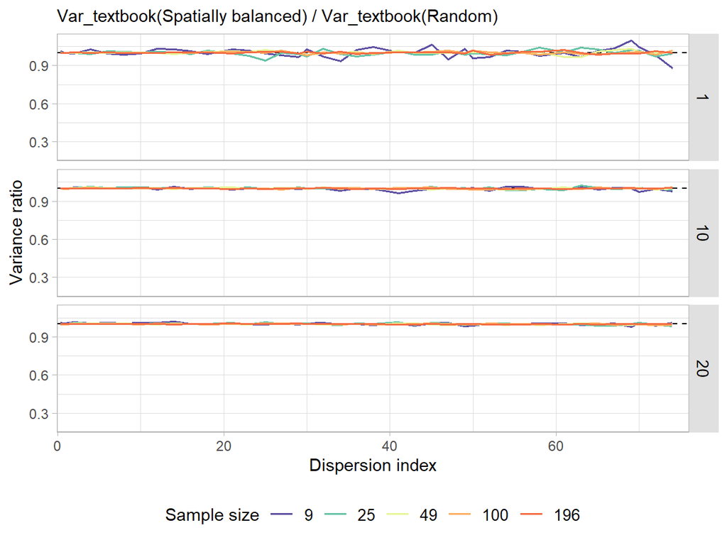